# Biol3207_ass2_Acidification_Effects_on_Behaviour

Angeline Sun

2022-10-30

###Topic Acidification_Effects_on_Behaviour

###Assignment task The goal of this assignment is to conduct a meta-analysis on ocean acidification effects on behaviour. Recall the paper by Clark et al. (2020) that we worked on in week 6. This study was an experimental study across 5-6 different reef fish that looked at comparing the effect of elevated CO2 (in ppm) relative to some control on fish behaviour. That study, you might recall, did not find strong evidence that increased acidification had effects on behaviour.

Nonetheless, this was just a single study (albeit done on 6 species). In this assignment we want to use meta-analysis to:

1. estimate the overall effect of ocean acidification on behaviour and determine if these effects are general across studies conducting similar experiments;
2. understand how variable the effect size is within the literature
3. what factors (biological, methodological, publication practices) explain variation in effect size.

Using the skills that you have already learnt in the class you will be required to write a reproducible report in Rmarkdown. You have been provided with a number of files that you will use for the assignment. This includes:

1. The OA_activitydat_20190302_BIOL3207.csv data. You have already used this file, and should have code to bring it in, clean it up and create the necessary summary statistics you will need for the project. Pay close attention to what summary statistics you need! If you have forgotten what these data are about you can read the readme_BIOL3207.txt file.
2. The clark_paper_data.csv file contains the metadata for the Clark et al. (2020) paper that you will require for merging into the ocean_meta_data.csv file. The meaning of all the columns can be found in the meta-data_ocean_meta.csv file. You only need the meta-data_ocean_meta.csv file to understand what the columns mean, otherwise, you can ignore it.
3. The ocean_meta_data.csv file is the file you will use for the meta-analysis, graphing, interpretation and writing the report. The meaning of all the columns can be found in the meta-data_ocean_meta.csv file. You only need the meta-data_ocean_meta.csv file to understand what the columns mean, otherwise, you can ignore it.

### Assessment

The assessment is worth 40% of your final mark. You are to work independently on your reports. You will be assessed on three major areas: i) Statistical Analysis and Interpretation; ii) Reproducibility and iii) Coding, Writing Structure & Presentation. Below we detail in each section what we are looking for:

## provide the link to my GitHub Repo.

`(https://github.com/AngeleneSun/week6_3207QingyuSun/blob/main/README.md)`

#1. Statistical Analysis and Interpretation (50%) 1. Correct analysis of Clark et al. (2020) data (i.e., OA_activitydat_20190302_BIOL3207.csv) to generate the summary statistics (means, SD, N) for each of the fish species’ average activity for each treatment.

```r
## Install several packages
library(pacman)
library(orchaRd)
p_load(tidyverse, flextable, janitor, ggpmisc, metafor, patchwork)

## Read the Clark et al. (2020) data (i.e., OA_activitydat_20190302_BIOL3207.csv) and select meaningful columns

ass1_data <- read.csv("C:/Users/26935/OneDrive/桌面/3207 ass2/OA_activitydat_20190302_BIOL3207.csv")%>%
  dplyr::select(loc, species, treatment, animal_id, sl, size, activity, comment) %>% mutate(c(residual = 1:n()))
```

```r
## Do a check of the data by turning variables to factors
ass1_data$loc <- as.factor(ass1_data$loc)
ass1_data$species <- as.factor(ass1_data$species)
ass1_data$size <- as.factor(ass1_data$size)
ass1_data$treatment <- as.factor(ass1_data$treatment)

summary(ass1_data)
```

```
##         loc           species      treatment     animal_id            sl
##  AIMS 2015: 66   acantho  :196   CO2    :283   Min.   :   1.0   Min.   : 7.50
##  LIRS 2014:195   ambon    : 44   control:306   1st Qu.: 125.0   1st Qu.:11.50
##  LIRS 2016:328   chromis  : 34                 Median : 227.0   Median :24.00
##                  humbug   :142                 Mean   : 281.7   Mean   :26.16
##                  lemon    : 51                 3rd Qu.: 320.0   3rd Qu.:35.25
##                  whitedams:122                 Max.   :9696.0   Max.   :92.53
##                                                NA's   :32
##     size        activity        comment          c(residual = 1:n())
##  big  :394   Min.   : 1.025   Length:589         Min.   :  1
##  small:195   1st Qu.:18.622   Class :character   1st Qu.:148
##              Median :27.720   Mode  :character   Median :295
##              Mean   :28.143                      Mean   :295
##              3rd Qu.:37.476                      3rd Qu.:442
##              Max.   :57.573                      Max.   :589
##              NA's   :7
```

```r
###In the summary, we know that "animal_id" and "activity" have the NA values.  However, the data cannot be affected if "animal_id" not exist, so we only consider deleting the NA "activity" values.And also by checking the data, there is no any strange errors like spelling, capital, etc.

### Find where does the NA values distributes and whether have influence on data effect
table(ass1_data[!complete.cases(ass1_data$activity),] %>% select(loc, species))
```

```
##            species
## loc         acantho ambon chromis humbug lemon whitedams
##   AIMS 2015       0     0       0      0     0         0
##   LIRS 2014       2     1       0      2     2         0
##   LIRS 2016       0     0       0      0     0         0
```

```r
## Concentrate on loc "LIRS 2014" but no other locations and species "acantho", "ambon","humbug","lemon".
```

```r
library(dplyr)
attach(ass1_data)
ass1_data[is.na(activity),]
```

```
##           loc species treatment animal_id       sl size activity
## 9   LIRS 2014   ambon       CO2       222 34.00000  big       NA
## 34  LIRS 2014  humbug       CO2      9696 78.00000  big       NA
## 35  LIRS 2014  humbug       CO2      7877 68.00000  big       NA
## 73  LIRS 2014 acantho   control       900 78.00000  big       NA
## 74  LIRS 2014 acantho   control       876 68.00000  big       NA
## 220 LIRS 2014   lemon   control        59 24.12296  big       NA
## 221 LIRS 2014   lemon   control        60 26.50905  big       NA
##              comment c(residual = 1:n())
## 9   recording failed                   9
## 34  recording failed                  34
## 35  recording failed                  35
## 73  recording failed                  73
## 74  recording failed                  74
## 220 Recording failed                 220
## 221 Recording failed                 221
```

```r
ass2_data <- ass1_data[complete.cases(ass1_data$activity),]## delete NA activity value and it also because that rows will inhibit calculate statistical values

str(ass2_data)## If we want to know a bit more about the new data(i.e.,ass_data) we can also use the str() function. As can be seen in the image below, the data has 582 rows and nine columns by deleting 7 NA "activity" values. Moreover, we can see the data type of the different variables (columns).
```

```
## 'data.frame':    582 obs. of  9 variables:
##  $ loc                : Factor w/ 3 levels "AIMS 2015","LIRS 2014",..: 2 2 2 2 2 2 2 2 2 2 ...
##  $ species            : Factor w/ 6 levels "acantho","ambon",..: 2 2 2 2 5 2 5 2 2 2 ...
##  $ treatment          : Factor w/ 2 levels "CO2","control": 1 1 1 1 1 1 1 1 1 1 ...
##  $ animal_id          : int  64 65 67 68 74 75 81 84 85 88 ...
##  $ sl                 : num  57 38.2 39.3 36.1 36.4 ...
##  $ size               : Factor w/ 2 levels "big","small": 1 1 1 1 1 1 1 1 1 1 ...
##  $ activity           : num  8.15 10.51 6.51 27.84 36.68 ...
##  $ comment            : chr  "27min means of sml+lrg dur, from All Lizard activity data for JJ v2_7 Jun 2017.xlsx" "27min means of sml+lrg dur, from All Lizard activity data for JJ v2_7 Jun 2017.xlsx" "27min means of sml+lrg dur, from All Lizard activity data for JJ v2_7 Jun 2017.xlsx" "27min mea…
##  $ c(residual = 1:n()): Named int  1 2 3 4 5 6 7 8 10 11 ...
##   ..- attr(*, "names")= chr [1:582] "residual1" "residual2" "residual3" "residual4" ...
```

```r
##While the percentage of NA data is near to the original sample data, so we may realize this change didn't do some negative impact to our statistical data distribution.

res <- ass2_data %>% group_by(species, treatment) %>% summarise(mean= mean(activity), sd= sd(activity), n= n())
res## The summary statistics (means, SD, N) for each of the fish species’ average activity for each treatment
```

```
## # A tibble: 12 × 5
## # Groups:   species [6]
##    species   treatment  mean    sd     n
##    <fct>     <fct>     <dbl> <dbl> <int>
##  1 acantho   CO2        26.4 10.8     95
##  2 acantho   control    27.9 11.7     99
##  3 ambon     CO2        18.4 12.2     22
##  4 ambon     control    17.3 11.5     21
##  5 chromis   CO2        24.8 11.0     14
##  6 chromis   control    26.1  9.13    20
##  7 humbug    CO2        39.8 12.2     69
##  8 humbug    control    35.7 13.8     71
##  9 lemon     CO2        26.0 11.0     19
## 10 lemon     control    19.8 12.3     30
## 11 whitedams CO2        24.3  9.95    61
## 12 whitedams control    26.6 10.9     61
```

```r
##Another type of the data summary.Each has its own advantages and disadvantages.
# calculate mean,SD and N of activity across each species and treatment
other_res <- ass2_data %>% group_by(species, treatment) %>% summarise(mean = mean(activity),sd = sd(activity),n = n(),.groups = "drop") %>%
pivot_wider(names_from = treatment,values_from = c(mean,n,sd))##After the summary, all grouping structures of the current data set are deleted and the data set returns to its previous ungrouped state by using [.groups = "drop"].

# Change colnames of all columns in order to merge with the next metadata
colnames(other_res) <- c("Species","oa.mean", "ctrl.mean", "oa.n","ctrl.n", "oa.sd","ctrl.sd")
other_res
```

```
## # A tibble: 6 × 7
##   Species   oa.mean ctrl.mean  oa.n ctrl.n oa.sd ctrl.sd
##   <fct>       <dbl>     <dbl> <int>  <int> <dbl>   <dbl>
## 1 acantho      26.4      27.9    95     99 10.8    11.7
## 2 ambon        18.4      17.3    22     21 12.2    11.5
## 3 chromis      24.8      26.1    14     20 11.0     9.13
## 4 humbug       39.8      35.7    69     71 12.2    13.8
## 5 lemon        26.0      19.8    19     30 11.0    12.3
## 6 whitedams    24.3      26.6    61     61  9.95   10.9
```

2. Through coding, merge the summary statistics generated from 1) with the metadata (i.e., clark_paper_data.csv) from Clark et al. (2020).

```r
ass3_data <- read.csv("C:/Users/26935/OneDrive/桌面/3207 ass2/clark_paper_data.csv")
df <- merge(ass3_data, other_res, all=TRUE)
df ###Here is the merged.data with summary statistics generated from 1) with the metadata (i.e., clark_paper_data.csv)
```

```
##   Study     Authors Year..online. Year..print.
## 1   a92 Clark et al          2020         2020
## 2   a92 Clark et al          2020         2020
## 3   a92 Clark et al          2020         2020
## 4   a92 Clark et al          2020         2020
## 5   a92 Clark et al          2020         2020
## 6   a92 Clark et al          2020         2020
##                                                                    Title
## 1 Ocean acidification does not impair the behaviour of coral reef fishes
## 2 Ocean acidification does not impair the behaviour of coral reef fishes
## 3 Ocean acidification does not impair the behaviour of coral reef fishes
## 4 Ocean acidification does not impair the behaviour of coral reef fishes
## 5 Ocean acidification does not impair the behaviour of coral reef fishes
## 6 Ocean acidification does not impair the behaviour of coral reef fishes
##   Journal Pub.year.IF X2017.IF Average.n Effect.type Climate..FishBase.
```

[output cut: 20 more lines]

3. Through coding, correctly merge the combined summary statistics and metadata from Clark et al. (2020) (output from 1 & 2) into the larger meta-analysis dataset (i.e., ocean_meta_data.csv).

```r
ass4_data <- read.csv("C:/Users/26935/OneDrive/桌面/3207 ass2/ocean_meta_data.csv")
glimpse(ass4_data)##Have a glimpse of the information amount of ocean_meta_data
```

```
## Rows: 818
## Columns: 22
## $ Study              <chr> "a1", "a1", "a1", "a1", "a1", "a1", "a1", "a2", "a2…
## $ Authors            <chr> "Munday et al", "Munday et al", "Munday et al", "Mu…
## $ Year..online.      <int> 2009, 2009, 2009, 2009, 2009, 2009, 2009, 2009, 200…
## $ Year..print.       <int> 2009, 2009, 2009, 2009, 2009, 2009, 2009, 2010, 201…
## $ Title              <chr> "Ocean acidification impairs olfactory discriminati…
## $ Journal            <chr> "PNAS", "PNAS", "PNAS", "PNAS", "PNAS", "PNAS", "PN…
## $ Pub.year.IF        <chr> "9.432", "9.432", "9.432", "9.432", "9.432", "9.432…
## $ X2017.IF           <chr> "9.504", "9.504", "9.504", "9.504", "9.504", "9.504…
## $ Average.n          <int> 27, 27, 27, 27, 27, 27, 27, 15, 15, 15, 15, 15, 15,…
## $ Effect.type        <chr> "Strong", "Strong", "Strong", "Strong", "Strong", "…
## $ Species            <chr> "Amphiprion percula", "Amphiprion percula", "Amphip…
## $ Climate..FishBase. <chr> "Trop", "Trop", "Trop", "Trop", "Trop", "Trop", "Tr…
## $ Env.cue.stimulus.  <chr> "Yes", "Yes", "Yes", "Yes", "Yes", "Yes", "Yes", "Y…
## $ Cue.stimulus.type  <chr> "Habitat", "Habitat", "Habitat", "Habitat", "Kin", …
## $ Behavioural.metric <chr> "% time in Xanthostemon cue", "% time in Melaleuca …
## $ Life.stage         <chr> "Larvae", "Larvae", "Larvae", "Larvae", "Larvae", "…
## $ ctrl.n             <int> 26, 20, 20, 10, 30, 30, 30, 45, 45, 45, 45, 45, 45,…
## $ ctrl.mean          <dbl> 94.1290, 0.7830, 46.3800, 98.8260, 0.9120, 90.8760,…
## $ ctrl.sd            <dbl> 2.9931, 3.5017, 14.0023, 1.8563, 2.9960, 3.9984, 3.…
## $ oa.n               <int> 46, 46, 46, 16, 20, 20, 20, 45, 45, 45, 45, 45, 45,…
## $ oa.mean            <dbl> 72.7890, 83.5620, 71.4290, 88.2580, 99.8180, 99.818…
## $ oa.sd              <dbl> 13.2730, 10.6211, 13.2730, 7.0440, 0.0045, 0.0045, …
```

```r
# load the package
library(dplyr)
#print(distinct(ass4_data))(## Delete duplicated data rows found no repeated though,because the data.frame is too long, so I hide it by #)
```

```r
### Already moved to the question1, below is for reappear some significant info!!

##In order to combine the metadata from Clark et al. (2020) (output from 1 & 2) with the new data(i.e., ocean_meta_data.csv), we need to fix the columns which contains the same information into the common name.

#For the control groups, use the same name " ctrl" with the ocean_meta_data.csv.
library(dplyr)
ctrl <- levels(ass2_data$treatment)[levels(ass2_data$treatment)=="control"]
#For the CO2 groups, use the same name "oa" with the ocean_meta_data.csv.
oa <- levels(ass2_data$treatment)[levels(ass2_data$treatment)=="CO2"]
summary(ass2_data)
```

```
##         loc           species      treatment     animal_id           sl
##  AIMS 2015: 66   acantho  :194   CO2    :280   Min.   :  1.0   Min.   : 7.50
##  LIRS 2014:188   ambon    : 43   control:302   1st Qu.:125.2   1st Qu.:11.50
##  LIRS 2016:328   chromis  : 34                 Median :226.5   Median :23.99
##                  humbug   :140                 Mean   :249.5   Mean   :25.83
##                  lemon    : 49                 3rd Qu.:317.8   3rd Qu.:35.00
##                  whitedams:122                 Max.   :691.0   Max.   :92.53
##                                                NA's   :32
##     size        activity        comment          c(residual = 1:n())
##  big  :387   Min.   : 1.025   Length:582         Min.   :  1.0
##  small:195   1st Qu.:18.622   Class :character   1st Qu.:151.2
##              Median :27.720   Mode  :character   Median :298.5
##              Mean   :28.143                      Mean   :297.4
##              3rd Qu.:37.476                      3rd Qu.:443.8
##              Max.   :57.573                      Max.   :589.0
##
```

```r
# calculate mean,SD and N of activity across each species and treatment
other_res <- ass2_data %>% group_by(species, treatment) %>% summarise(mean = mean(activity),sd = sd(activity),n = n(),.groups = "drop") %>%
pivot_wider(names_from = treatment,values_from = c(mean,n,sd))
other_res
```

```
## # A tibble: 6 × 7
##   species   mean_CO2 mean_control n_CO2 n_control sd_CO2 sd_control
##   <fct>        <dbl>        <dbl> <int>     <int>  <dbl>      <dbl>
## 1 acantho       26.4         27.9    95        99  10.8       11.7
## 2 ambon         18.4         17.3    22        21  12.2       11.5
## 3 chromis       24.8         26.1    14        20  11.0        9.13
## 4 humbug        39.8         35.7    69        71  12.2       13.8
## 5 lemon         26.0         19.8    19        30  11.0       12.3
## 6 whitedams     24.3         26.6    61        61   9.95      10.9
```

```r
# Change colnames of all columns in order to merge with the next metadata
colnames(other_res) <- c("Species", "oa.mean", "ctrl.mean", "oa.n", "ctrl.n", "oa.sd", "ctrl.sd")
other_res
```

```
## # A tibble: 6 × 7
##   Species   oa.mean ctrl.mean  oa.n ctrl.n oa.sd ctrl.sd
##   <fct>       <dbl>     <dbl> <int>  <int> <dbl>   <dbl>
## 1 acantho      26.4      27.9    95     99 10.8    11.7
## 2 ambon        18.4      17.3    22     21 12.2    11.5
## 3 chromis      24.8      26.1    14     20 11.0     9.13
## 4 humbug       39.8      35.7    69     71 12.2    13.8
## 5 lemon        26.0      19.8    19     30 11.0    12.3
## 6 whitedams    24.3      26.6    61     61  9.95   10.9
```

```r
##Thus, we combine the metadata from Clark et al. (2020) (output from 1 & 2) with the new data(i.e., ocean_meta_data.csv)
merge_3data <- merge(ass4_data, df,all= TRUE)
merge_3data
```

[output not shown]

[output cut: 6585 more lines]

```r
###Here is the merged.data with summary statistics generated from Clark & 2) with the larger meta-analysis dataset (i.e., ocean_meta_data.csv) though lots of NA.
str(merge_3data)##the data has 824 rows and 22 columns.
```

```
## 'data.frame':    824 obs. of  22 variables:
##  $ Study             : chr  "a1" "a1" "a1" "a1" ...
##  $ Authors           : chr  "Munday et al" "Munday et al" "Munday et al" "Munday et al" ...
##  $ Year..online.     : int  2009 2009 2009 2009 2009 2009 2009 2011 2012 2012 ...
##  $ Year..print.      : int  2009 2009 2009 2009 2009 2009 2009 2012 2012 2012 ...
##  $ Title             : chr  "Ocean acidification impairs olfactory discrimination and homing ability of marine fish." "Ocean acidification impairs olfactory discrimination and homing ability of marine fish." "Ocean acidification impairs olfactory discrimination and homing ability of marine fish."…
##  $ Journal           : chr  "PNAS" "PNAS" "PNAS" "PNAS" ...
##  $ Pub.year.IF       : chr  "9.432" "9.432" "9.432" "9.432" ...
##  $ X2017.IF          : chr  "9.504" "9.504" "9.504" "9.504" ...
##  $ Average.n         : int  27 27 27 27 27 27 27 69 17 17 ...
##  $ Effect.type       : chr  "Strong" "Strong" "Strong" "Strong" ...
##  $ Species           : chr  "Amphiprion percula" "Amphiprion percula" "Amphiprion percula" "Amphiprion percula" ...
##  $ Climate..FishBase.: chr  "Trop" "Trop" "Trop" "Trop" ...
##  $ Env.cue.stimulus. : chr  "Yes" "Yes" "Yes" "Yes" ...
##  $ Cue.stimulus.type : chr  "Habitat" "Habitat" "Habitat" "Habitat" ...
##  $ Behavioural.metric: chr  "% time in anemone cue" "% time in Grass cue" "% time in Melaleuca cue" "% time in Xanthostemon cue" ...
##  $ Life.stage        : chr  "Larvae" "Larvae" "Larvae" "Larvae" ...
##  $ ctrl.n            : int  10 20 20 26 30 30 30 70 17 17 ...
##  $ ctrl.mean         : num  98.826 46.38 0.783 94.129 96.35 ...
##  $ ctrl.sd           : num  1.86 14 3.5 2.99 4 ...
##  $ oa.n              : int  16 46 46 46 20 20 20 68 17 17 ...
##  $ oa.mean           : num  88.3 71.4 83.6 72.8 49.6 ...
##  $ oa.sd             : num  7.04 13.27 10.62 13.27 2.45 ...
```

4. Correctly calculate the log response ratio (lnRR) effect size for every row of the dataframe using metafor’s escalc() function.

```r
##Concerning the ass3_data, some numeric variables are in integer which are not good for describing them, so we change all of them to numeric by using read_csv.
data <- merge_3data %>% mutate(across(.cols=where(is.integer), .fns=as.numeric))#Convert Multiple Columns From Integer to Numeric Type in R

# Here we need to change "-" in "Pub.year.IF" and "X2017.IF" to NA as numeric format for further calculation.
unique(data$Pub.year.IF[is.na(as.numeric(data$Pub.year.IF))])
```

```
## [1] "-"
```

```r
unique(data$X2017.IF[is.na(as.numeric(data$X2017.IF))])
```

```
## [1] "-"
```

```r
#Thus, change "-"to NA
data[data=="-"] <- NA
summary(data)##Let's see the characterstic of the dataset!
```

```
##     Study             Authors          Year..online.   Year..print.
##  Length:824         Length:824         Min.   :2009   Min.   :2009
##  Class :character   Class :character   1st Qu.:2012   1st Qu.:2013
##  Mode  :character   Mode  :character   Median :2015   Median :2015
##                                        Mean   :2015   Mean   :2015
##                                        3rd Qu.:2017   3rd Qu.:2018
##                                        Max.   :2020   Max.   :2020
##     Title             Journal          Pub.year.IF          X2017.IF
##  Length:824         Length:824         Length:824         Length:824
##  Class :character   Class :character   Class :character   Class :character
##  Mode  :character   Mode  :character   Mode  :character   Mode  :character
##
##
##
##    Average.n      Effect.type          Species          Climate..FishBase.
##  Min.   :  4.00   Length:824         Length:824         Length:824
##  1st Qu.: 12.00   Class :character   Class :character   Class :character
##  Median : 17.00   Mode  :character   Mode  :character   Mode  :character
##  Mean   : 28.69
##  3rd Qu.: 30.00
##  Max.   :568.00
##  Env.cue.stimulus.  Cue.stimulus.type  Behavioural.metric  Life.stage
##  Length:824         Length:824         Length:824         Length:824
##  Class :character   Class :character   Class :character   Class :character
##  Mode  :character   Mode  :character   Mode  :character   Mode  :character
##
##
##
##      ctrl.n         ctrl.mean            ctrl.sd               oa.n
##  Min.   :  4.00   Min.   :   -69.78   Min.   :    0.000   Min.   :  2.00
##  1st Qu.: 10.00   1st Qu.:     1.08   1st Qu.:    1.176   1st Qu.: 11.00
##  Median : 18.00   Median :     9.52   Median :    5.867   Median : 18.00
##  Mean   : 29.15   Mean   :   435.63   Mean   :  103.754   Mean   : 29.06
##  3rd Qu.: 30.00   3rd Qu.:    43.11   3rd Qu.:   21.524   3rd Qu.: 34.00
##  Max.   :752.00   Max.   :154936.88   Max.   :25490.446   Max.   :755.00
##     oa.mean              oa.sd
##  Min.   :   -59.67   Min.   :    0.00
##  1st Qu.:     1.21   1st Qu.:    1.17
##  Median :    12.37   Median :    7.26
##  Mean   :   435.34   Mean   :  113.65
##  3rd Qu.:    43.32   3rd Qu.:   22.05
##  Max.   :157061.25   Max.   :36812.37
```

```r
### Fittingly, we can use the Log response ratio (lnRR), since the mean treatment between the two groups is significantly different.
data_lnRR <- metafor::escalc(measure = "ROM", data=data ,m1i = oa.mean, m2i = ctrl.mean, sd1i = oa.sd, sd2i = ctrl.sd,n1i = oa.n, n2i = ctrl.n,var.names = c("lnRR", "VRR"))
##When there is NA in lnRR, it means that one of the mean value of one kind of treatment is positive, while the other is negative, so it couldn't be calculated, just reflects the difference sample in different treatments from the baseline.
```

```r
# If we select the NA in lnRR, we will see that in Behavioural.metric column, they all have "change"&"rate".
test <- subset(data_lnRR,is.na(lnRR))%>% select(Behavioural.metric, ctrl.mean,oa.mean,Study,lnRR)
test
```

```
##
##                                             Behavioural.metric ctrl.mean
## 12         Change in area use, experienced tutor, water, Fig 2     0.195
## 13       Change in area use, pseudo-conditioning, water, Fig 1     0.179
## 14         Change in area use, true conditioning, water, Fig 1    -0.069
## 16                            Change in area use, water, Fig 4    -0.076
## 19  Change in feeding strikes, true conditioning, water, Fig 1     3.009
## 23     Change in line crosses, experienced tutor, water, Fig 2    -2.250
## 31      Change in area use, experienced tutor, predator, Fig 2    -1.995
## 34    Change in area use, pseudo-conditioning, predator, Fig 1    -0.441
## 35      Change in area use, true conditioning, predator, Fig 1    -2.687
## 116                     Mean change bite rate, empty bag, Fig2     1.005
## 119                   Mean change shelter use, empty bag, Fig2    -1.119
## 122                        Mean change shelter use, goby, Fig2    -2.797
## 180                   Prop change feeding strikes, Day 1, sham     0.054
```

[output cut: 34 more lines]

```r
##Hence,we do a calculation to figure out what the proportion of the related change& rate in all experiments.
# See which studies have the NA value in lnRR.
NAsty <- unique(data_lnRR[!complete.cases(data_lnRR$lnRR),]$Study)
# And see how many the specific related change& rate words appear in the former selected studies.
rela <- data_lnRR %>% filter(Study %in% NAsty) %>%  filter(grepl("change|Change|rate",Behavioural.metric)) %>% nrow()
##As the result showed, there is 104 experiments have the related words.

# See how many experiments in total in studies.
tota <- data_lnRR %>% filter(Study %in% NAsty) %>% nrow()
##As the result showed, there is 109 experiments in total.
print(paste(
"Specific words appearing time:",rela,
",Total experiment time:",tota,
",specific words appearing time in the total experiment times:",rela/tota))
```

```
## [1] "Specific words appearing time: 104 ,Total experiment time: 109 ,specific words appearing time in the total experiment times: 0.954128440366973"
```

```r
# Thus, what we want to know is that 104/109 is the proportion of related specific words appearing time in the total experiment times. Which high proportion makes the lnRR not to be believed.

##We removed the conditions where have a NA in lnRR, and compare the effect size difference in the previous selected studies and the others by testing lnRR and VRR.
# Remove NA and label specific studies and the one in "NAsty"
data1 <- data_lnRR %>%filter(!is.na(lnRR)) %>%
         mutate(chan = (Study %in% NAsty)|grepl("change|Change",Behavioural.metric))
data1
```

[output not shown]

[output cut: 6402 more lines]

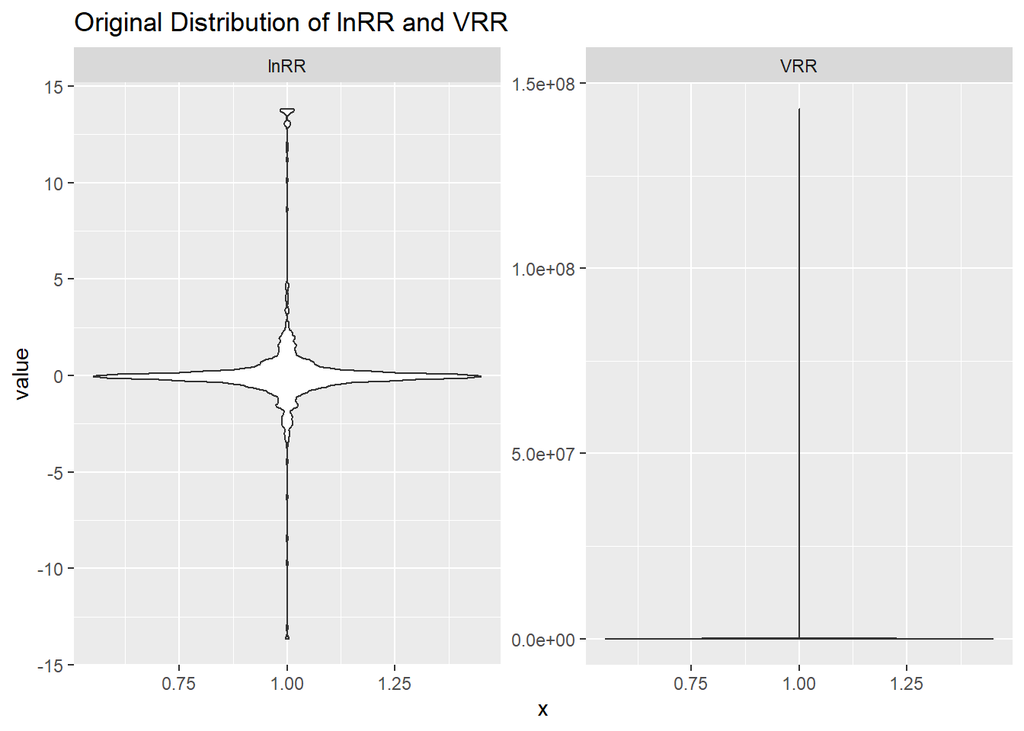

```r
## Do a test on the distribution while the size of the changed lnRR and its variance VlnRR. And plots below.
data1 %>% select(lnRR, VRR) %>% pivot_longer(cols = lnRR:VRR, names_to = "nu") %>%
      ggplot(aes(x=1,y = value)) + geom_violin() + facet_wrap(~nu, scale = "free") + ggtitle("Original Distribution of lnRR and VRR")
```

```r
##Calibration, by setting sqrt(VRR)> 2*abs(lnRR)) & (sqrt(VRR)> log(1.5) as standard, to prevent too much deviation.Get rid of points with outrageous variance values.
data1 %>% filter( (sqrt(VRR) > 2*abs(lnRR)) & (sqrt(VRR)> log(1.5) )) %>% select(Study,ctrl.n:VRR)
```

```
##
##    Study ctrl.n ctrl.mean   ctrl.sd oa.n   oa.mean     oa.sd    lnRR
## 1    a11     17   -6.0000   13.9155   17   -7.0000   16.4924  0.1542
## 2    a11     17   -2.2810   10.1263   17   -4.2110   15.1895  0.6131
## 3    a11     17   -0.1260    0.7092   17   -0.2520    1.1339  0.6931
## 4    a11     23    0.3590    0.8057   23    0.2870    0.8632 -0.2238
## 5    a11     17   -0.8770    5.7888   17   -1.4040    8.6791  0.4706
## 6    a11     16   -7.6220   14.4400   16   -0.4010    9.6280 -2.9448
## 7    a11     23   -2.6090    8.8243   23   -2.8990    9.7307  0.1054
## 8    a11     15   -4.9320   10.5035   15   -6.9040   16.2355  0.3364
## 9    a11     23    1.5230    6.6950   23    2.4110   10.9537  0.4594
## 10   a11     16   -0.5280   10.5560   16   -3.5190   11.2600  1.8968
## 11   a11     15   -1.9400   13.2960   15   -5.0750   20.8095  0.9616
## 12   a12     25    0.5480    0.3424   25    0.0010    0.7411 -6.3063
## 13   a21     20   27.2610   54.8910   20   36.0470   55.4679  0.2794
```

[output cut: 136 more lines]

```r
##Removing them.
data2 <- data1 %>% filter((sqrt(VRR) <= 2*abs(lnRR)) | (sqrt(VRR) <= log(1.5) ))
print(paste("Initial number of experiment:",nrow(data),
            "by deleting:",nrow(data2)))
```

```
## [1] "Initial number of experiment: 824 by deleting: 727"
```

```r
# Saving it by writing the file to a csv file
write_csv(data2,"data2.csv")
##In this part,The sample size decreases by 97 untrustworthy points, which makes our results more reliable no matter how the validity of the meta-analysis changes.
```

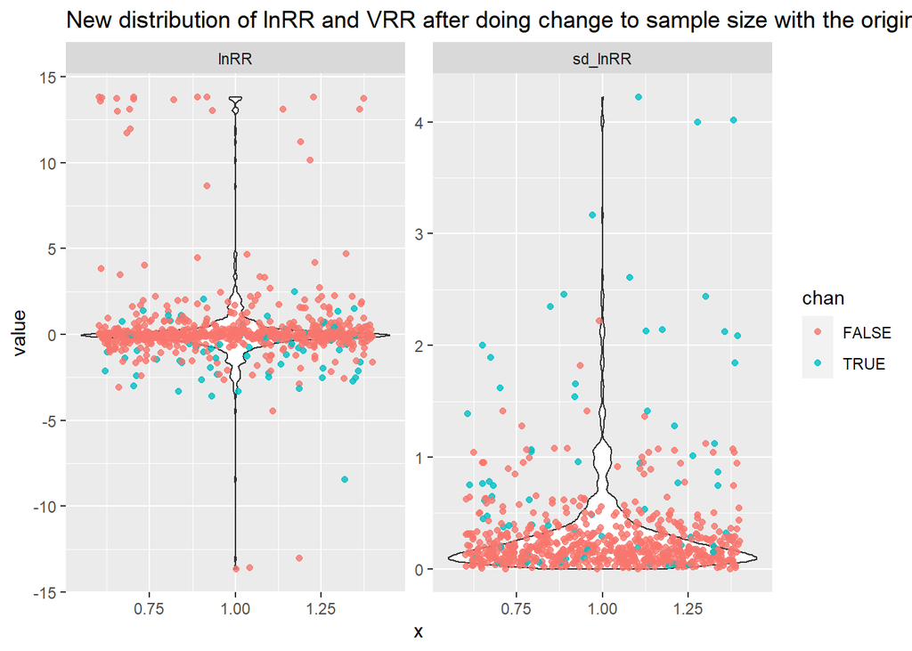

```r
##THus, we test the after-changed distribution again by showing them and use different color to distinguish.
data2 %>% mutate(sd_lnRR = sqrt(VRR)) %>% select(lnRR, sd_lnRR, chan) %>% pivot_longer(cols = c(lnRR,sd_lnRR), names_to = "g",values_to = "value") %>% ggplot(aes(x = 1,y = value)) + geom_violin() +geom_jitter(alpha = 0.8,aes(color = chan))+ facet_wrap(~g, scale = "free") + ggtitle("New distribution of lnRR and VRR after doing change to sample size with the origin")
```

```r
##In this plot, we could find the some points still have a large effect values and the sampling variance still has some extreme values by deleting some untrustworthy points and including measurement. Usually which have large effect values and VRR is the experiments that measuring change proportion .
```

# Fig2.”New distribution of lnRR and VRR after doing change to sample size with the origin”

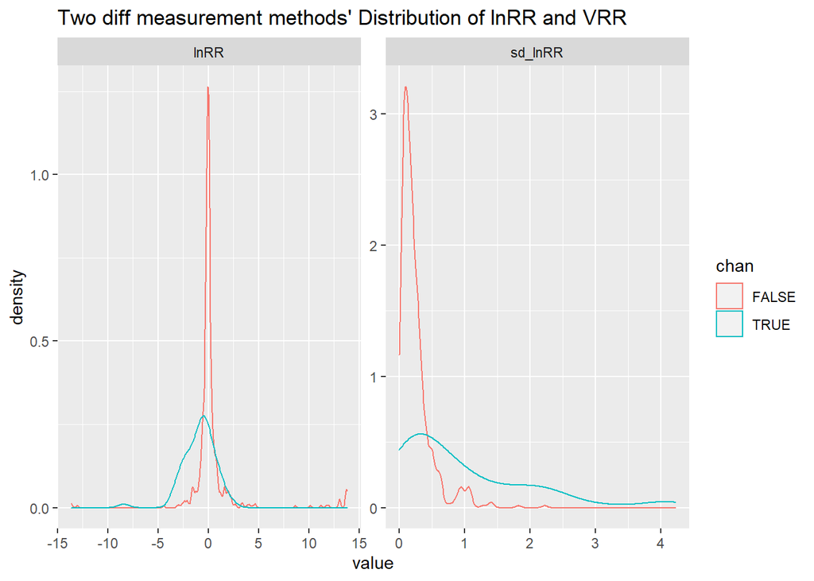

```r
#And we could see the distribution difference of two measurement methods data clearer through the density plot.
data2 %>% mutate(sd_lnRR = sqrt(VRR)) %>% select(lnRR, sd_lnRR, chan) %>% pivot_longer(cols = c(lnRR,sd_lnRR), names_to = "c", values_to = "value") %>%  ggplot(aes(x = value)) + geom_density(aes(color = chan)) + facet_wrap(~c, scale = "free") + ggtitle("Two diff measurement methods' Distribution of lnRR and VRR ")
```

```r
##It could be easier to find the experiments that measuring change proportion have large effect values and VRR.
```

#Fig3. “Two diff measurement methods’ Distribution of lnRR and VRR”

##5&6 together below 5. Correct meta-analytic model fitted to the data that controls for the sampling variance of lnRR. The model should include a random effect of study and observation. Use metafor’s rma.mv() function. 6. Written paragraph of the findings and what they mean which is supported with a figure. The paragraph should include:

1. Correct presentation and interpretation of overall meta-analytic mean and measures of uncertainty around the mean estimate (e.g., 95% confidence intervals).
2. Measures of heterogeneity in effect size estimates across studies (i.e., I2 and/or prediction intervals - see predict() function in metafor)
3. Forest plot showing the mean estimate, 95% confidence interval, and prediction interval with clearly labelled axes, number of samples and studies plotted on figure.

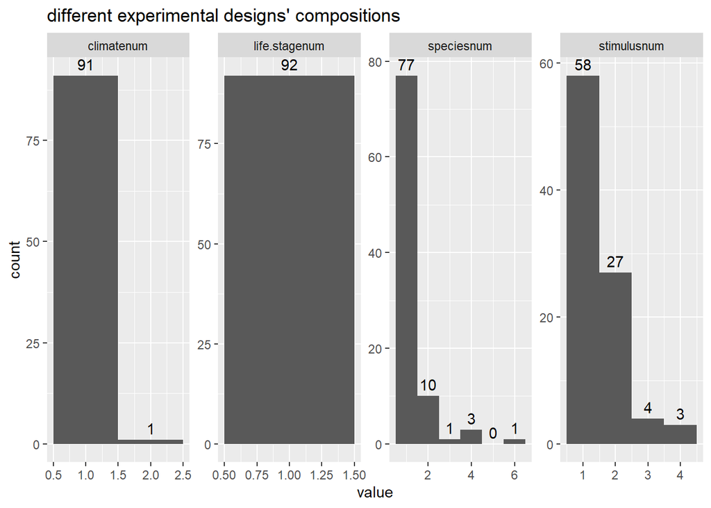

```r
##In order to find the most appropriate random effect of the study and observation values, we need to make clear the composition of the experimental design of different studies first, so as to satisfy the multi-level meta-analysis model.
##Where use the file "data2" here.
data2 %>% group_by(Study) %>%
    summarise(climatenum = length(unique(Climate..FishBase.)), speciesnum = length(unique(Species)), life.stagenum = length(unique(Life.stage)),stimulusnum= length(unique(Cue.stimulus.type))) %>%
    pivot_longer(cols = -1,names_to = "d", values_to = "value") %>%
    ggplot(aes(x = value)) + geom_histogram(binwidth = 1) + geom_text(aes(label=as.character(..count..)),stat="bin",binwidth=1,vjust=-0.5) +  facet_wrap(~d,scale = "free",nrow = 1) + ggtitle("different experimental designs' compositions")
```

```r
##Here we see how do these studies allocate their materials number and methods.These fishes almost live in the same climate condition(except one different) and the same life stage, so the two aspects didn't influence most because almost the same. And we speculate that the variance of each studies is caused by the species and stimulus methods.
```

#Fig4. “different experimental designs’ compositions”

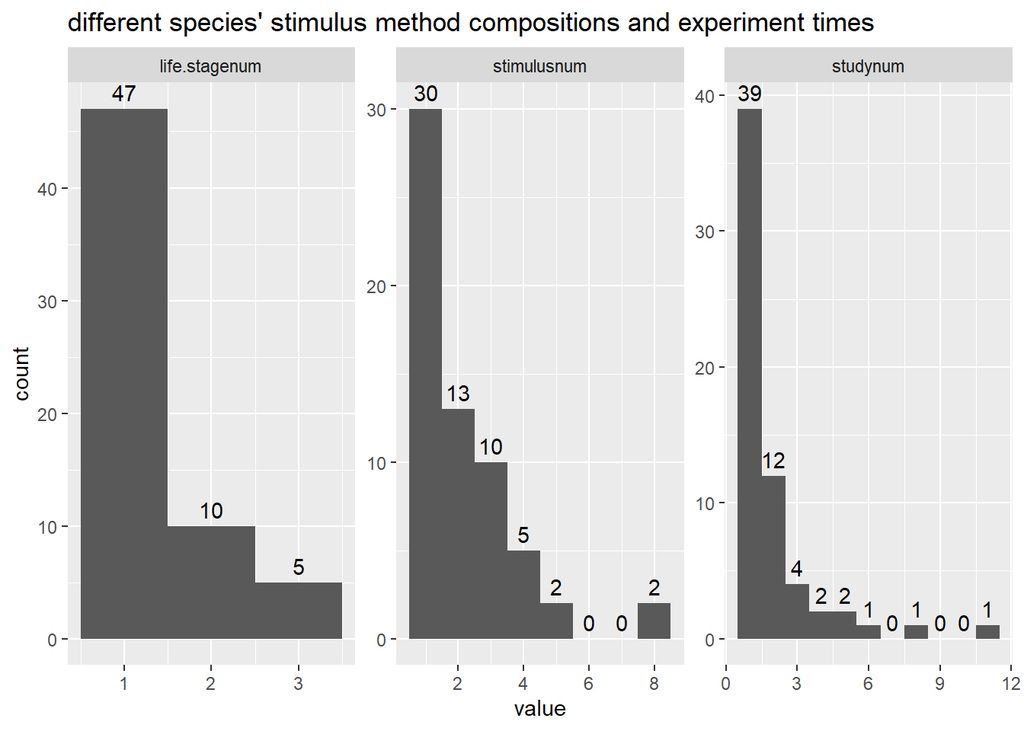

```r
##Thus we use the same way to count the life stages of each species, stimulus types,studies amounts.
data2 %>% group_by(Species) %>%
    summarise(studynum = length(unique(Study)), life.stagenum = length(unique(Life.stage)),stimulusnum= length(unique(Cue.stimulus.type))) %>%
    pivot_longer(cols = -1,names_to = "d", values_to = "value") %>%
    ggplot(aes(x = value)) + geom_histogram(binwidth = 1) + geom_text(aes(label=as.character(..count..)),stat="bin",binwidth=1,vjust=-0.5) +  facet_wrap(~d,scale = "free") + ggtitle("different species' stimulus method compositions and experiment times")
```

```r
##In the plot, the studies mainly focused on a life stage in these species, more than half of the total species are all in a study and seldom does the studies use the same species, near to half of the species are under the stimulus where more than 2 types in all experiments.
```

#Fig5.”different species’ stimulus method compositions and experiment times”

##Based on the two histogram plots, it could be found that almost publications are willing to use only 1 specie in a life stage to conduct a study, while only 1 climate area if involved several species. Always every studies will contain 1-2 methods of stimulus. So in a study, the variance is caused most by the stimulus involved and study number.

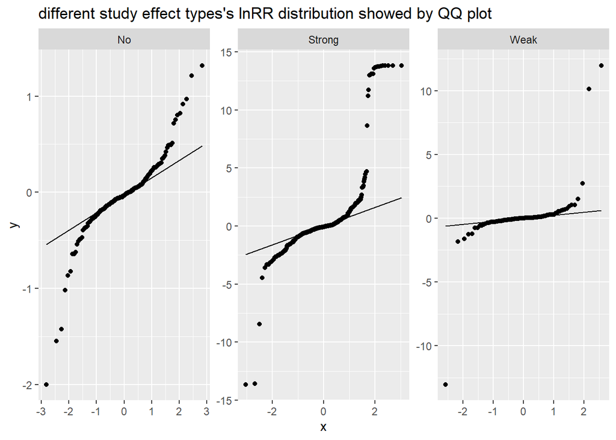

```r
##In order to know whether the difference are randomly caused by each factor effects and whether the factor's lnRR fits the normal distribution.
# Using QQ plot to show different types of effect, aiming to reflect the total distribution differences by normal distribution.
data2 %>% ggplot(aes(sample = lnRR)) + stat_qq() + stat_qq_line() + facet_wrap(~Effect.type,scale = "free") +  ggtitle ("different study effect types's lnRR distribution showed by QQ plot")
```

```r
##We could see the QQ plots are definitely not normal distribution and lots of extreme values, but nearly according to a point on the axis x equals 0 presents a central symmetry, because we don't know how the method used to calculate the value and also the effect.type could have different functions to diff species.
```

#Fig6. “different study effect types’s lnRR distribution showed by QQ plot”

```r
##Based on last finding, we are going to calculate the all factors' lnRR.
alldis <- function(data,factors){
allplot <- tibble()
for (i in factors){
group <- ensym(i)
alldata <- data %>% group_by({{group}}) %>% summarise(mean_lnRR = mean(lnRR)) %>% select(mean_lnRR) %>% mutate(fa = as.character(i))
allplot <- rbind(alldata,allplot)
   }
allplot %>% ggplot(aes(sample = mean_lnRR)) + stat_qq() + stat_qq_line() + facet_wrap(~fa,scale = "free") + ylab("lnRR mean") + ggtitle( "lnRR mean of all factors in experiment by QQ plot")
}
```

# Fig7.”lnRR mean of all factors in experiment by QQ plot”

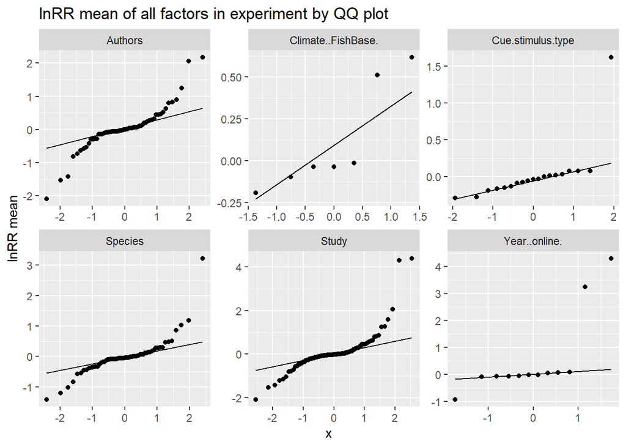

```r
alldis(data2,c("Species","Study","Climate..FishBase.","Cue.stimulus.type","Year..online.","Authors"))
```

```r
##In this figure, only the effect of Cue.stimulus.type is a normal distribution, others are big deviation.

###Hence, based on all the factors, the main random effect could be "Study". A model of meta-analysis could be made by 1) the diff variance in diff groups caused by "Cue.stimulus.type" as diff cues in studies(when a species in a position may have diff stimulus/cues with other species in the system) ,and 2)other variances lead by diff situations like species and experiment settings.

data3 <- data2 %>% group_by(Study) %>% mutate(cal = 1:n()) %>% ungroup()##Here I use cal to calculate the amount of each studies.

#The meta-analytic model in multi-level
Model <- metafor::rma.mv(yi=lnRR~1, V = VRR, data = data3, method = "REML", random = list(~1|Study, ~1|Species, ~1|cal),dfs = "contain", test = "t")##Cannot have "Cue.stimulus.type" here because it has NA values.
print(Model)
```

```
##
## Multivariate Meta-Analysis Model (k = 727; method: REML)
##
## Variance Components:
##
##             estim    sqrt  nlvls  fixed   factor
## sigma^2.1  0.1562  0.3952     92     no    Study
## sigma^2.2  0.0992  0.3150     62     no  Species
## sigma^2.3  0.8502  0.9221     41     no      cal
##
## Test for Heterogeneity:
## Q(df = 726) = 736088995.6408, p-val < .0001
##
## Model Results:
##
## estimate      se    tval  df    pval   ci.lb   ci.ub
##   0.5163  0.1586  3.2554  40  0.0023  0.1957  0.8368  **
##
## ---
## Signif. codes:  0 '***' 0.001 '**' 0.01 '*' 0.05 '.' 0.1 ' ' 1
```

```r
##We can see from above that the model estimates an overall meta-analytic mean as 0.516 with a 95% confidence interval of 0.1957 to 0.8368. In other words, for each variation by an average of 0.516.But in this condition, The p-value is 0.0023 less than 0.05 and the difference by using species, experimental methods and variables between diff experiments is large still should be considered.

##When turning lnRR to RR(respone ratio)
p_MLMA <- predict(Model, transf = exp)
p_MLMA
```

```
##
##    pred  ci.lb  ci.ub  pi.lb   pi.ub
##  1.6757 1.2162 2.3089 0.1954 14.3731
```

```r
##and measuring of heterogeneity in effect size estimates across studies I^2(square):
#For calculating I^2:
library(orchaRd)
I2_vals <- orchaRd::i2_ml(Model)
I2 <- tibble(type = firstup(gsub("I2_", "", names(I2_vals))), I2 = round(I2_vals,4))
flextable(I2) %>%
   align(part = "header", align = "center") %>%
   compose(part = "header", j = 1, value = as_paragraph(as_b("Type"))) %>%
   compose(part = "header", j = 2, value = as_paragraph(as_b("I"), as_b(as_sup("2")), as_b("(%)")))
```

| Type | I2(%) |
| --- | --- |
| Total | 100.0000 |
| Study | 14.1244 |
| Species | 8.9745 |
| Cal | 76.9011 |

#Table1. Measuring of heterogeneity in effect size estimates across studies I^2(square) by meta-analysis model

##From the previous table, we could see the variance in total is 100%, and 14.12% for study, 8.97% for species, and 76.90% for cal, which means our data has a large heterogeneous and the experimental methods, measurements and experiment itself is highly variable.

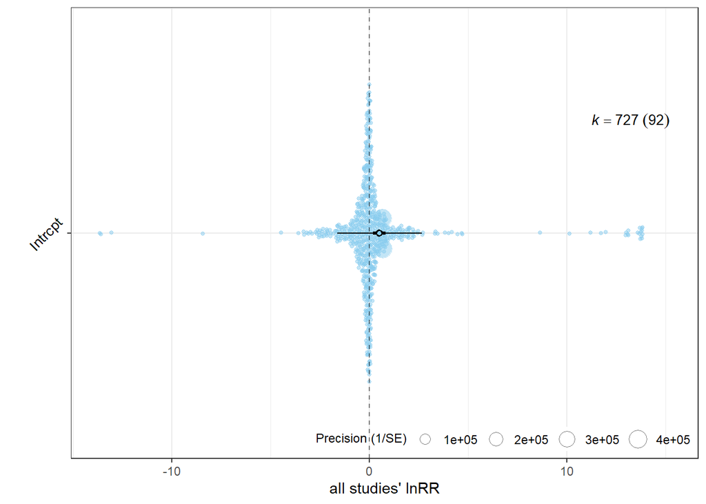

```r
##Using a orchard plot for the multi-level meta-analysis.
orchaRd::orchard_plot(Model, mod = "1", group = "Study", data = data3,
    xlab = "all studies' lnRR", angle = 45)##Some points still have extreme values and where the sampling size is extremely big for some experiments.The outcome is related with Model we did before(meta-analytic mean as 0.516 with a 95% confidence interval of 0.1957 to 0.8368).
```

```r
##Overall compared analysis of external factors like climate and methods.

#Firstly, explore how does external factors like climate effect lnRR changing. There is no doubt that different regions under different temperature conditions have different influences on the content of CO2 in seawater, so the degree of acidification of seawater under different temperature conditions will be different.
##Remove some without habitat points
climate <- data3 %>% filter(Climate..FishBase. != "Not provided")
MLMR <- metafor::rma.mv(lnRR ~ Climate..FishBase.-1, V = VRR, method = "REML",
                         random = list(~1|Species, ~1|Study/cal),
dfs = "contain", test = "t", data = climate)
MLMR##From the table results, we could realize that the mean lnRR varies largely in different habitats, such as: From the highest in deep water is 0.51, to the lowest in subtropic water is -0.174, no matter how the p-value is although all is above 0.14. That is to say that" In different places, there has a different effect adaptations of OA.
```

```
##
## Multivariate Meta-Analysis Model (k = 721; method: REML)
##
## Variance Components:
##
##             estim    sqrt  nlvls  fixed     factor
## sigma^2.1  0.2396  0.4895     61     no    Species
## sigma^2.2  0.3281  0.5728     91     no      Study
## sigma^2.3  4.1897  2.0469    721     no  Study/cal
##
## Test for Residual Heterogeneity:
## QE(df = 715) = 10983689.7769, p-val < .0001
##
## Test of Moderators (coefficients 1:6):
## F(df1 = 6, df2 = 55) = 0.4724, p-val = 0.8258
##
## Model Results:
##
##                            estimate      se     tval   df    pval    ci.lb
## Climate..FishBase.Boreal    -0.0368  0.8273  -0.0445   55  0.9646  -1.6947
## Climate..FishBase.Deep       0.5100  1.6530   0.3085   55  0.7589  -2.8028
## Climate..FishBase.Polar     -0.1065  0.7132  -0.1494   85  0.8816  -1.5245
## Climate..FishBase.Subtrop   -0.1736  0.2440  -0.7116   55  0.4797  -0.6625
## Climate..FishBase.Temp      -0.0931  0.3175  -0.2932  715  0.7694  -0.7164
## Climate..FishBase.Trop       0.2925  0.2004   1.4597   55  0.1500  -0.1091
##                             ci.ub
## Climate..FishBase.Boreal   1.6210
## Climate..FishBase.Deep     3.8227
## Climate..FishBase.Polar    1.3114
## Climate..FishBase.Subtrop  0.3153
## Climate..FishBase.Temp     0.5302
## Climate..FishBase.Trop     0.6942
##
## ---
## Signif. codes:  0 '***' 0.001 '**' 0.01 '*' 0.05 '.' 0.1 ' ' 1
```

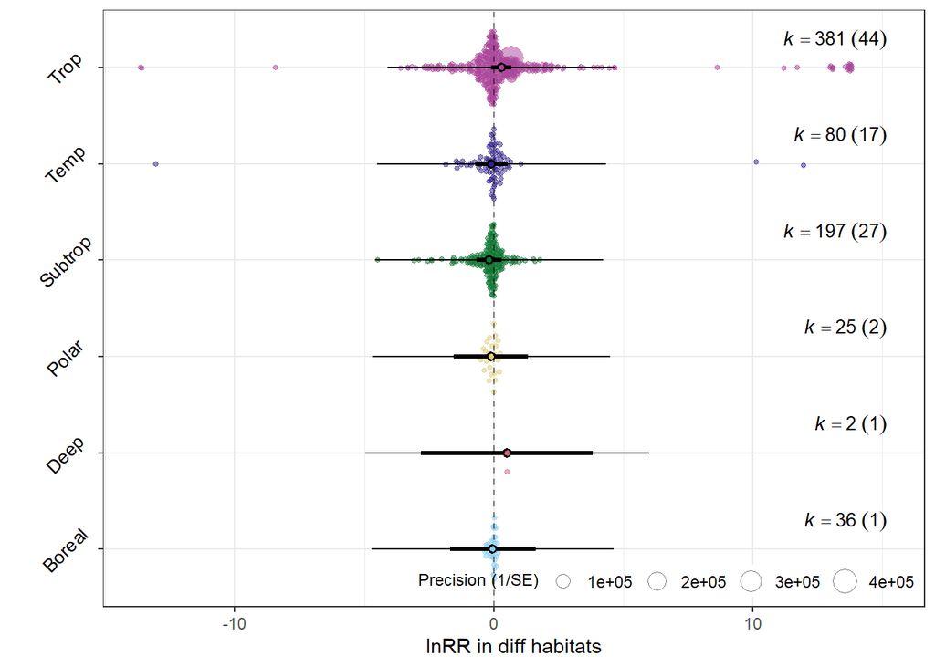

```r
##Orchard plot for diff habitats!
orchaRd::orchard_plot(MLMR, mod = "Climate..FishBase.", group = "Study", data = climate,
    xlab = "lnRR in diff habitats", angle = 45)##It can seen that except deep water and trop water, all the habitats have the mean lnRR nearly 0. Why it will deviate, it's because of the experiment has a large sampling size or it has some extreme points.
```

# Fig8. “lnRR in diff habitats”

```r
##Secondly, let's figure out how does the influence of OA differs to diff life stage! Using the same methods.
##Remove some without stage points
stage <- data3 %>% filter(Life.stage != "Not provided")
MLMR_1 <- metafor::rma.mv(lnRR ~ Life.stage-1, V = VRR, method = "REML",
                         random = list(~1|Species, ~1|Study/cal),
dfs = "contain", test = "t", data = stage)
MLMR_1##From the table results, we could realize that the mean lnRR varies largely in different life stages, such as: only larvae has the largest postive mean lnRR, but adult and juvenile both negative reflected in effect size. That is to say that" In different life stages, there has a different effect adaptations of OA.
```

```
##
## Multivariate Meta-Analysis Model (k = 701; method: REML)
##
## Variance Components:
##
##             estim    sqrt  nlvls  fixed     factor
## sigma^2.1  0.2581  0.5080     58     no    Species
## sigma^2.2  0.3067  0.5538     89     no      Study
## sigma^2.3  4.3245  2.0795    701     no  Study/cal
##
## Test for Residual Heterogeneity:
## QE(df = 698) = 735922424.1940, p-val < .0001
##
## Test of Moderators (coefficients 1:3):
## F(df1 = 3, df2 = 86) = 1.0949, p-val = 0.3558
##
## Model Results:
##
##                     estimate      se     tval  df    pval    ci.lb   ci.ub
## Life.stageAdult      -0.1113  0.2696  -0.4129  86  0.6807  -0.6473  0.4247
## Life.stageJuvenile   -0.0764  0.2057  -0.3714  86  0.7113  -0.4853  0.3325
## Life.stageLarvae      0.3491  0.2125   1.6427  86  0.1041  -0.0734  0.7715
##
## ---
## Signif. codes:  0 '***' 0.001 '**' 0.01 '*' 0.05 '.' 0.1 ' ' 1
```

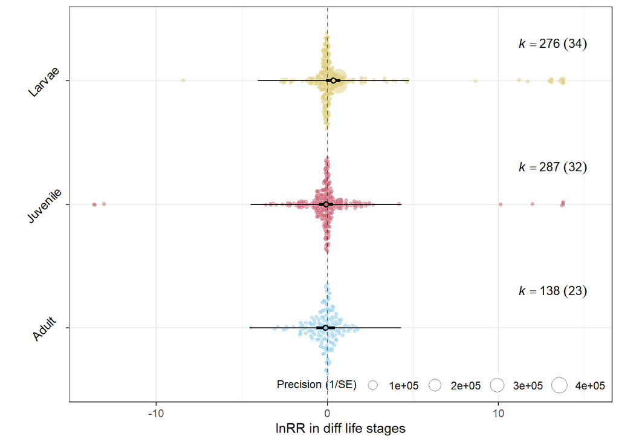

```r
##Orchard plot for diff life stages!
orchaRd::orchard_plot(MLMR_1, mod = "Life.stage", group = "Study", data = stage,
    xlab = "lnRR in diff life stages", angle = 45)##Where the larvae stage have the precise and accurate studies than the two stages maybe because of the positive effect size.
```

# Fig9.”lnRR in diff life stages”

```r
##Thirdly, let's combine life stage and climate together what we found before.
##Remove some points
cs <- data3 %>% filter(Life.stage!= "Not provided" & Climate..FishBase. != "Not provided")
MLMR_2 <- metafor::rma.mv(lnRR ~ Life.stage + Climate..FishBase.-1, V = VRR, method = "REML",
                         random = list(~1|Species, ~1|Study/cal),
dfs = "contain", test = "t", data = cs)
MLMR_2
```

```
##
## Multivariate Meta-Analysis Model (k = 701; method: REML)
##
## Variance Components:
##
##             estim    sqrt  nlvls  fixed     factor
## sigma^2.1  0.2565  0.5065     58     no    Species
## sigma^2.2  0.3053  0.5526     89     no      Study
## sigma^2.3  4.3424  2.0839    701     no  Study/cal
##
## Test for Residual Heterogeneity:
## QE(df = 693) = 10870099.1077, p-val < .0001
##
## Test of Moderators (coefficients 1:8):
## F(df1 = 8, df2 = 50) = 0.8032, p-val = 0.6027
##
## Model Results:
##
##                            estimate      se     tval  df    pval    ci.lb
## Life.stageAdult             -0.5057  0.8938  -0.5658  81  0.5731  -2.2842
## Life.stageJuvenile          -0.5406  0.8745  -0.6181  81  0.5382  -2.2806
## Life.stageLarvae            -0.0368  0.8263  -0.0446  81  0.9645  -1.6808
## Climate..FishBase.Deep       1.0505  1.8889   0.5562  50  0.5806  -2.7434
## Climate..FishBase.Polar      0.4294  1.1288   0.3804  81  0.7046  -1.8166
## Climate..FishBase.Subtrop    0.1198  0.8791   0.1363  50  0.8922  -1.6459
## Climate..FishBase.Temp       0.3082  0.9110   0.3382  81  0.7361  -1.5045
## Climate..FishBase.Trop       0.6574  0.8679   0.7575  50  0.4523  -1.0858
##                             ci.ub
## Life.stageAdult            1.2727
## Life.stageJuvenile         1.1995
## Life.stageLarvae           1.6072
## Climate..FishBase.Deep     4.8445
## Climate..FishBase.Polar    2.6754
## Climate..FishBase.Subtrop  1.8855
## Climate..FishBase.Temp     2.1208
## Climate..FishBase.Trop     2.4005
##
## ---
## Signif. codes:  0 '***' 0.001 '**' 0.01 '*' 0.05 '.' 0.1 ' ' 1
```

```r
##Let see the three types of methods how to show on VRR.
V <- as.data.frame(orchaRd::r2_ml(MLMR))
V <- cbind(V,as.data.frame(orchaRd::r2_ml(MLMR_1)))
V <- cbind(V,as.data.frame(orchaRd::r2_ml(MLMR_2)))
colnames(V) <- c("climate","life stage","climate + life stage")
knitr::kable(V,caption = "Variance varied by different meta-analysis models in publication bias")
```

Variance varied by different meta-analysis models in publication bias

|  | climate | life stage | climate + life stage |
| --- | --- | --- | --- |
| R2_marginal | 0.0097977 | 0.0092748 | 0.0239997 |
| R2_conditional | 0.1279633 | 0.1237205 | 0.1358094 |

```r
##Here is to proved our prediction, by using two variables together could better illustrate the variance in diff experiments. And the constant variance could only larger slightly than 0.02,because in diff experiments, it varies a lot.
```